# 第1回: tidyverse の紹介など

- 2018-04-16 16:00--
- データなどは https://github.com/wcornwell/R_short_course にあるので，`git clone` もしくは `zip` ダウンロード
- 配布資料: [dplyr と tidyr を使ったデータラングリングチートシート](https://www.rstudio.com/wp-content/uploads/2015/09/data-wrangling-japanese.pdf)

やったこと

- RStudio インストール，起動
- `R_short_course` ディレクトリにRStudio Project を作る
- `tidyverse` について
  - インストールして，ロード
  - Windows で Rcpp 関連で失敗している場合は [Rtools](https://cran.rstudio.com/bin/windows/Rtools/) を入れるとよいかも
  - 一度失敗すると依存解決してくれなくなるみたいなので，根気よくエラーメッセージを読んで順番にパッケージをインストールする
- `data.frame` とは
  - universal input and output
  - `tibble` も
  - most data can be tidy
- `readr` について
  - `string` と `factor`
  - デフォルトで`stringsAsFactors=FALSE`
- `tibble` について
  - `[` と `[[`
- `dplyr`

```r
date()
```

'Tue Apr 24 13:21:39 2018'

```r
library(readr)
```

```r
data <- read.csv("R_short_course/data/plantHeight5Spp.csv")
```

```r
head(data)
```

| sort_number | site | Genus_species | Family | growthform | height | loght | Country | Site | lat | ... | rain.wetm | rain.drym | rain.seas | rain.wetqr | rain.dryqr | rain.warmqr | rain.coldqr | LAI | NPP | hemisphere |
| --- | --- | --- | --- | --- | --- | --- | --- | --- | --- | --- | --- | --- | --- | --- | --- | --- | --- | --- | --- | --- |
| 10147 | 27 | Darwinia_leptantha | Myrtaceae | Shrub | 0.8 | -0.09691001 | Australia | Kuringai Chase, Sydney | 33.650 | ... | 157 | 63 | 29 | 450 | 208 | 385 | 279 | 4.14 | 1563 | -1 |
| 8499 | 118 | Colocasia_esculenta | Araceae | Herb | 0.6 | -0.22184875 | NA | Marshall Islands | 9.000 | ... | 300 | 82 | 34 | 870 | 305 | 855 | 405 | NA | NA | 1 |
| 3140 | 178 | Apocynum_cannabinum | Apocynaceae | Herb | 1.5 | 0.17609126 | USA | Indiana Dunes | 41.617 | ... | 104 | 44 | 23 | 299 | 165 | 299 | 165 | 3.26 | 1131 | 1 |
| 11039 | 54 | Dysphania_myriocephala | Amaranthaceae | Herb | 0.1 | -1.00000000 | Australia | Central Australia | 23.800 | ... | 37 | 9 | 42 | 109 | 35 | 109 | 42 | 1.32 | 756 | -1 |
| 5215 | 123 | Bruguiera_gymnorrhiza | Rhizophoraceae | Tree | 25.0 | 1.39794001 | Micronesia | Yap | 9.500 | ... | 368 | 144 | 31 | 1055 | 436 | 689 | 489 | NA | NA | 1 |
| 19989 | 103 | Miconia_aulocalyx | Melastomataceae | NA | 3.0 | 0.47712126 | Peru | Manu | 12.183 | ... | 416 | 99 | 45 | 1177 | 340 | 928 | 359 | 4.26 | 1405 | -1 |

```r
library(dplyr)
```

```r
data %>% select(site) %>% head()
```

| site |
| --- |
| 27 |
| 118 |
| 178 |
| 54 |
| 123 |
| 103 |

- `filter`: データの選択

```r
data %>% filter(Country == "Australia")
```

| sort_number | site | Genus_species | Family | growthform | height | loght | Country | Site | lat | ... | rain.wetm | rain.drym | rain.seas | rain.wetqr | rain.dryqr | rain.warmqr | rain.coldqr | LAI | NPP | hemisphere |
| --- | --- | --- | --- | --- | --- | --- | --- | --- | --- | --- | --- | --- | --- | --- | --- | --- | --- | --- | --- | --- |
| 10147 | 27 | Darwinia_leptantha | Myrtaceae | Shrub | 0.80 | -0.09691001 | Australia | Kuringai Chase, Sydney | 33.650 | ... | 157 | 63 | 29 | 450 | 208 | 385 | 279 | 4.14 | 1563 | -1 |
| 11039 | 54 | Dysphania_myriocephala | Amaranthaceae | Herb | 0.10 | -1.00000000 | Australia | Central Australia | 23.800 | ... | 37 | 9 | 42 | 109 | 35 | 109 | 42 | 1.32 | 756 | -1 |
| 10229 | 106 | Dendrocnide_peltata | Urticaceae | Tree | 30.00 | 1.47712125 | Australia | Christmas Island | 10.417 | ... | 309 | 16 | 66 | 806 | 92 | 659 | 135 | 4.51 | 2296 | -1 |
| 12088 | 24 | Eucalyptus_leptophylla | Myrtaceae | Tree | 6.00 | 0.77815125 | Australia | Adelaide - Brookfield Mallee | 34.320 | ... | 30 | 15 | 23 | 83 | 49 | 50 | 79 | 2.14 | 773 | -1 |
| 25144 | 30 | Pultenaea_daphnoides | Fabaceae - P | Shrub | 3.00 | 0.47712126 | Australia | Kuringai - Diatreme | 33.578 | ... | 159 | 64 | 29 | 455 | 212 | 391 | 280 | 4.51 | 1435 | -1 |
| 12043 | 55 | Eucalyptus_gillenii | Myrtaceae | Shrub | 5.00 | 0.69897000 | Australia | Alice - the gap | 23.795 | ... | 37 | 9 | 42 | 109 | 35 | 109 | 42 | 1.32 | 756 | -1 |
| 12091 | 21 | Eucalyptus_incrassata | Myrtaceae | Tree | 8.00 | 0.90308999 | Australia | Adelaide - ferries | 35.235 | ... | 45 | 18 | 29 | 127 | 59 | 60 | 127 | 2.17 | 661 | -1 |
| 4331 | 42 | Banksia_hookeriana | Proteaceae | Shrub | 1.71 | 0.23299611 | Australia | Western Australia | 29.867 | ... | 117 | 5 | 83 | 292 | 29 | 30 | 292 | 1.67 | 75 | -1 |
| 11715 | 38 | Eremaea_pauciflora | Myrtaceae | Shrub | 1.10 | 0.04139268 | Australia | Perth - Melaleuca Park | 31.689 | ... | 160 | 8 | 84 | 426 | 33 | 39 | 426 | 1.51 | 575 | -1 |
| 4917 | 37 | Bossiaea_eriocarpa | Fabaceae - P | Shrub | 0.70 | -0.15490196 | Australia | Perth - Darling Scarp | 32.020 | ... | 213 | 13 | 85 | 566 | 50 | 54 | 566 | 1.93 | 708 | -1 |
| 26023 | 58 | Rhodanthe_floribunda | Asteraceae | Herb | 0.20 | -0.69897000 | Australia | Kunoth Paddock - Alice Springs | 23.533 | ... | 41 | 11 | 42 | 121 | 40 | 121 | 46 | 1.01 | 605 | -1 |
| 11513 | 29 | Epacris_microphylla | Ericaceae | Shrub | 0.80 | -0.09691001 | Australia | Kuringai - Challenger | 33.595 | ... | 160 | 65 | 29 | 458 | 213 | 392 | 283 | 4.51 | 1435 | -1 |
| 13086 | 16 | Gahnia_sp | Cyperaceae | Herb | 1.30 | 0.11394335 | Australia | Bunyip - Melbourne | 38.010 | ... | 107 | 52 | 20 | 313 | 176 | 176 | 275 | 2.71 | 793 | -1 |
| 12090 | 23 | Eucalyptus_sp4 | Myrtaceae | Tree | 10.00 | 1.00000000 | Australia | Adelaide - Brookfield Chenopod | 34.347 | ... | 31 | 15 | 23 | 84 | 49 | 51 | 80 | 2.14 | 773 | -1 |
| 18212 | 43 | Leucopogon_sp1 | Ericaceae | Shrub | 2.00 | 0.30103000 | Australia | Armidale - Goonoowigal | 29.815 | ... | 105 | 37 | 33 | 287 | 133 | 287 | 133 | 3.26 | 1272 | -1 |
| 11724 | 53 | Eremophila_maitlandii | Scrophulariaceae | Shrub | 2.05 | 0.31175386 | Australia | WA | 24.650 | ... | 50 | 0 | 83 | 127 | 5 | 54 | 108 | 1.51 | 464 | -1 |
| 32688 | 20 | Allocasuarina_sp | Casuarinaceae | Shrub | 3.00 | 0.47712126 | Australia | Adelaide - Cox's scrub | 35.341 | ... | 96 | 22 | 47 | 272 | 75 | 75 | 272 | 2.14 | 695 | -1 |
| 20912 | 12 | Nothofagus_cunninghami | Fagaceae | Tree | 32.00 | 1.50514998 | Australia | Mt Field, Tasmania | 42.679 | ... | 117 | 54 | 20 | 347 | 200 | 200 | 322 | 2.96 | 643 | -1 |
| 12099 | 15 | Eucalyptus_sp7 | Myrtaceae | Tree | 18.00 | 1.25527250 | Australia | Green's Bush - Melbourne | 38.430 | ... | 101 | 45 | 25 | 289 | 150 | 150 | 287 | 4.04 | 1023 | -1 |
| 15651 | 61 | Heteropogon_triticeus | Poaceae | Herb | 0.40 | -0.39794001 | Australia | Townsville savanna | 19.337 | ... | 251 | 9 | 101 | 668 | 33 | 626 | 42 | 4.14 | 1012 | -1 |
| 32320 | 100 | Xanthostemon_paradoxus | Myrtaceae | Tree | 7.00 | 0.84509804 | Australia | Howard Springs, Darwin | 12.494 | ... | 371 | 1 | 104 | 970 | 7 | 408 | 7 | 4.07 | 956 | -1 |
| 25159 | 8 | Pultenaea_juniperina | Fabaceae - P | Shrub | 1.50 | 0.17609126 | Australia | Huon Rd, Tasmania | 42.921 | ... | 115 | 63 | 17 | 311 | 205 | 205 | 296 | 2.82 | 743 | -1 |
| 2357 | 91 | Alloteropsis_semialata | Poaceae | Herb | 0.55 | -0.25963731 | Australia | Cape York | 14.967 | ... | 290 | 2 | 113 | 767 | 9 | 501 | 13 | 4.03 | 811 | -1 |
| 9565 | 101 | Cupaniopsis_anacardioides | Sapindaceae | Tree | 8.00 | 0.90308999 | Australia | Darwin - East point | 12.406 | ... | 428 | 1 | 106 | 1091 | 10 | 428 | 10 | 4.07 | 956 | -1 |
| 21140 | 49 | Olearia_elliptica | Asteraceae | Shrub | 2.80 | 0.44715803 | Australia | Toowoomba | 28.085 | ... | 92 | 32 | 35 | 258 | 111 | 258 | 111 | 2.51 | 1119 | -1 |
| 3970 | 11 | Atherosperma_moschatum | Atherospermataceae | Tree | 31.00 | 1.49136169 | Australia | Tasmania | 42.683 | ... | 182 | 72 | 23 | 530 | 280 | 280 | 495 | 2.96 | 643 | -1 |
| 12031 | 99 | Eucalyptus_miniata | Myrtaceae | Tree | 20.00 | 1.30103000 | Australia | Howard Springs, Darwin | 12.494 | ... | 371 | 1 | 104 | 970 | 7 | 408 | 7 | 4.07 | 956 | -1 |
| 150 | 57 | Acacia_aneura | Fabaceae - M | Shrub/Tree | 9.00 | 0.95424251 | Australia | Kunoth Paddock - Alice Springs | 23.533 | ... | 41 | 11 | 42 | 121 | 40 | 121 | 46 | 1.01 | 605 | -1 |
| 13286 | 87 | Gardenia_actinocarpa | Rubiaceae | Shrub/Tree | 3.50 | 0.54406804 | Australia | Queensland | 16.100 | ... | 365 | 27 | 86 | 1031 | 92 | 868 | 116 | 4.04 | 908 | -1 |
| 21743 | 62 | Paraserianthes_toona | Fabaceae - M | Tree | 16.00 | 1.20411998 | Australia | Townsville Vine Thicket | 19.332 | ... | 253 | 9 | 101 | 674 | 33 | 631 | 43 | 4.14 | 1012 | -1 |
| ... | ... | ... | ... | ... | ... | ... | ... | ... | ... |  | ... | ... | ... | ... | ... | ... | ... | ... | ... | ... |
| 21604 | 61 | Panicum_decompositum | Poaceae | Herb | 0.80 | -0.09691001 | Australia | Townsville savanna | 19.337 | ... | 251 | 9 | 101 | 668 | 33 | 626 | 42 | 4.14 | 1012 | -1 |
| 2994 | 12 | Anopterus_glandulosus | Escalloniaceae | Shrub | 3.50 | 0.54406804 | Australia | Mt Field, Tasmania | 42.679 | ... | 117 | 54 | 20 | 347 | 200 | 200 | 322 | 2.96 | 643 | -1 |
| 18213 | 43 | Leucopogon_sp2 | Ericaceae | Shrub | 2.20 | 0.34242268 | Australia | Armidale - Goonoowigal | 29.815 | ... | 105 | 37 | 33 | 287 | 133 | 287 | 133 | 3.26 | 1272 | -1 |
| 25160 | 8 | Pultenaea_obcordata | Fabaceae - P | Shrub | 3.20 | 0.50514998 | Australia | Huon Rd, Tasmania | 42.921 | ... | 115 | 63 | 17 | 311 | 205 | 205 | 296 | 2.82 | 743 | -1 |
| 5681 | 58 | Calotis_hispidula | Asteraceae | Herb | 0.20 | -0.69897000 | Australia | Kunoth Paddock - Alice Springs | 23.533 | ... | 41 | 11 | 42 | 121 | 40 | 121 | 46 | 1.01 | 605 | -1 |
| 6019 | 20 | Carex_sp | Cyperaceae | Herb | 0.40 | -0.39794001 | Australia | Adelaide - Cox's scrub | 35.341 | ... | 96 | 22 | 47 | 272 | 75 | 75 | 272 | 2.14 | 695 | -1 |
| 23724 | 101 | Polyalthia_australis | Annonaceae | Tree | 8.00 | 0.90308999 | Australia | Darwin - East point | 12.406 | ... | 428 | 1 | 106 | 1091 | 10 | 428 | 10 | 4.07 | 956 | -1 |
| 29652 | 62 | Strychnos_lucida | Loganiaceae | Shrub | 2.00 | 0.30103000 | Australia | Townsville Vine Thicket | 19.332 | ... | 253 | 9 | 101 | 674 | 33 | 631 | 43 | 4.14 | 1012 | -1 |
| 21584 | 27 | Panicum_simile | Poaceae | Herb | 0.40 | -0.39794001 | Australia | Kuringai Chase, Sydney | 33.650 | ... | 157 | 63 | 29 | 450 | 208 | 385 | 279 | 4.14 | 1563 | -1 |
| 30532 | 54 | Thyridolepis_mitchelliana | Poaceae | Herb | 0.30 | -0.52287874 | Australia | Central Australia | 23.800 | ... | 37 | 9 | 42 | 109 | 35 | 109 | 42 | 1.32 | 756 | -1 |
| 31032 | 55 | Triodia_brizioides | Poaceae | Herb | 0.65 | -0.18708664 | Australia | Alice - the gap | 23.795 | ... | 37 | 9 | 42 | 109 | 35 | 109 | 42 | 1.32 | 756 | -1 |
| 12100 | 37 | Eucalyptus_marginata | Myrtaceae | Tree | 22.00 | 1.34242268 | Australia | Perth - Darling Scarp | 32.020 | ... | 213 | 13 | 85 | 566 | 50 | 54 | 566 | 1.93 | 708 | -1 |
| 32697 | 38 | Adenanthos_cygnorum | Proteaceae | Tree | 7.00 | 0.84509804 | Australia | Perth - Melaleuca Park | 31.689 | ... | 160 | 8 | 84 | 426 | 33 | 39 | 426 | 1.51 | 575 | -1 |
| 32312 | 15 | Xanthorrhoea_sp2 | Xanthorrhoeaceae | Shrub | 4.00 | 0.60205999 | Australia | Green's Bush - Melbourne | 38.430 | ... | 101 | 45 | 25 | 289 | 150 | 150 | 287 | 4.04 | 1023 | -1 |
| 19248 | 30 | Macrozamia_communis | Zamiaceae | Shrub | 1.70 | 0.23044892 | Australia | Kuringai - Diatreme | 33.578 | ... | 159 | 64 | 29 | 455 | 212 | 391 | 280 | 4.51 | 1435 | -1 |
| 30395 | 61 | Themeda_triandra | Poaceae | Herb | 0.80 | -0.09691001 | Australia | Townsville savanna | 19.337 | ... | 251 | 9 | 101 | 668 | 33 | 626 | 42 | 4.14 | 1012 | -1 |
| 3998 | 23 | Atriplex_stipitata | Amaranthaceae | Shrub | 0.50 | -0.30103000 | Australia | Adelaide - Brookfield Chenopod | 34.347 | ... | 31 | 15 | 23 | 84 | 49 | 51 | 80 | 2.14 | 773 | -1 |
| 2356 | 100 | Alloteropsis_semialata | Poaceae | Herb | 2.00 | 0.30103000 | Australia | Howard Springs, Darwin | 12.494 | ... | 371 | 1 | 104 | 970 | 7 | 408 | 7 | 4.07 | 956 | -1 |
| 3972 | 12 | Atherosperma_moschatum | Atherospermataceae | Tree | 28.00 | 1.44715803 | Australia | Mt Field, Tasmania | 42.679 | ... | 117 | 54 | 20 | 347 | 200 | 200 | 322 | 2.96 | 643 | -1 |
| 4334 | 29 | Banksia_ericifolia | Proteaceae | Shrub | 2.60 | 0.41497335 | Australia | Kuringai - Challenger | 33.595 | ... | 160 | 65 | 29 | 458 | 213 | 392 | 283 | 4.51 | 1435 | -1 |
| 18104 | 21 | Leptospermum_continentale | Myrtaceae | Shrub | 2.80 | 0.44715803 | Australia | Adelaide - ferries | 35.235 | ... | 45 | 18 | 29 | 127 | 59 | 60 | 127 | 2.17 | 661 | -1 |
| 25016 | 8 | Pteridium_esculentum | Dennstaedtiaceae | Fern | 1.60 | 0.20411998 | Australia | Huon Rd, Tasmania | 42.921 | ... | 115 | 63 | 17 | 311 | 205 | 205 | 296 | 2.82 | 743 | -1 |
| 5607 | 43 | Callitris_endlicheri | Cupressaceae | Tree | 18.00 | 1.25527250 | Australia | Armidale - Goonoowigal | 29.815 | ... | 105 | 37 | 33 | 287 | 133 | 287 | 133 | 3.26 | 1272 | -1 |
| 20160 | 27 | Mirbelia_speciosa | Fabaceae - P | Shrub | 1.00 | 0.00000000 | Australia | Kuringai Chase, Sydney | 33.650 | ... | 157 | 63 | 29 | 450 | 208 | 385 | 279 | 4.14 | 1563 | -1 |
| 175 | 54 | Acacia_victoriae | Fabaceae - M | Shrub | 4.00 | 0.60205999 | Australia | Central Australia | 23.800 | ... | 37 | 9 | 42 | 109 | 35 | 109 | 42 | 1.32 | 756 | -1 |
| 16579 | 106 | Inocarpus_fagifer | Fabaceae - P | Tree | 30.00 | 1.47712125 | Australia | Christmas Island | 10.417 | ... | 309 | 16 | 66 | 806 | 92 | 659 | 135 | 4.51 | 2296 | -1 |
| 11028 | 86 | Dysoxylum_papuanum | Meliaceae | Tree | 27.50 | 1.43933269 | Australia | Cairns - Daintree canopy crane | 16.103 | ... | 459 | 26 | 93 | 1294 | 92 | 1031 | 108 | 4.04 | 908 | -1 |
| 12042 | 55 | Eucalyptus_gamophylla | Myrtaceae | Shrub | 5.50 | 0.74036269 | Australia | Alice - the gap | 23.795 | ... | 37 | 9 | 42 | 109 | 35 | 109 | 42 | 1.32 | 756 | -1 |
| 12057 | 30 | Eucalyptus_sp3 | Myrtaceae | Tree | 30.00 | 1.47712125 | Australia | Kuringai - Diatreme | 33.578 | ... | 159 | 64 | 29 | 455 | 212 | 391 | 280 | 4.51 | 1435 | -1 |
| 10144 | 29 | Darwinia_fascicularis | Myrtaceae | Shrub | 1.60 | 0.20411998 | Australia | Kuringai - Challenger | 33.595 | ... | 160 | 65 | 29 | 458 | 213 | 392 | 283 | 4.51 | 1435 | -1 |

- `arrange`: 並べ替え

```r
data %>% arrange(Country, Genus_species)
```

| sort_number | site | Genus_species | Family | growthform | height | loght | Country | Site | lat | ... | rain.wetm | rain.drym | rain.seas | rain.wetqr | rain.dryqr | rain.warmqr | rain.coldqr | LAI | NPP | hemisphere |
| --- | --- | --- | --- | --- | --- | --- | --- | --- | --- | --- | --- | --- | --- | --- | --- | --- | --- | --- | --- | --- |
| 1354 | 3 | Acaena_antarctica | Rosaceae | Herb | 0.10 | -1.00000000 | Argentina | Rio Turbio - Nothofagus | 51.578 | ... | 57 | 34 | 15 | 152 | 106 | 120 | 122 | 1.26 | 30 | -1 |
| 2347 | 51 | Allophylus_edulis | Sapindaceae | Tree | 15.00 | 1.17609126 | Argentina | Tucuman - Yungas South | 26.763 | ... | 184 | 10 | 82 | 472 | 33 | 472 | 34 | 1.51 | 596 | -1 |
| 4101 | 14 | Austrocedrus_chilensis | Cupressaceae | Tree | 35.00 | 1.54406804 | Argentina | Bariloche | 41.242 | ... | 175 | 28 | 56 | 443 | 106 | 106 | 443 | 4.14 | 691 | -1 |
| 4175 | 10 | Baccharis_divaricata | Asteraceae | Shrub | 0.50 | -0.30103000 | Argentina | Puerto Madryn - dune | 42.769 | ... | 28 | 9 | 35 | 77 | 36 | 37 | 55 | 1.01 | 404 | -1 |
| 4841 | 4 | Bolax_gummifera | Apiaceae | Herb | 0.08 | -1.09691001 | Argentina | Rio Turbio - heath | 51.575 | ... | 57 | 34 | 15 | 152 | 106 | 120 | 122 | 1.26 | 30 | -1 |
| 7841 | 4 | Chiliotrichum_diffusum | Asteraceae | Shrub | 0.27 | -0.56863624 | Argentina | Rio Turbio - heath | 51.575 | ... | 57 | 34 | 15 | 152 | 106 | 120 | 122 | 1.26 | 30 | -1 |
| 8053 | 9 | Chuquiraga_avellanedae | Asteraceae | Shrub | 0.90 | -0.04575749 | Argentina | Puerto Madryn - steppe | 42.790 | ... | 28 | 9 | 35 | 77 | 36 | 37 | 55 | 1.01 | 404 | -1 |
| 11379 | 4 | Empetrum_rubrum | Ericaceae | Shrub | 0.11 | -0.95860731 | Argentina | Rio Turbio - heath | 51.575 | ... | 57 | 34 | 15 | 152 | 106 | 120 | 122 | 1.26 | 30 | -1 |
| 12182 | 51 | Eugenia_uniflora | Myrtaceae | Tree | 10.00 | 1.00000000 | Argentina | Tucuman - Yungas South | 26.763 | ... | 184 | 10 | 82 | 472 | 33 | 472 | 34 | 1.51 | 596 | -1 |
| 12528 | 19 | Fabiana_sp | Solanaceae | Shrub | 0.50 | -0.30103000 | Argentina | Mendoza - Payunia | 36.250 | ... | 23 | 13 | 17 | 65 | 44 | 61 | 47 | 1.89 | 522 | -1 |
| 12621 | 4 | Festuca_gracillima | Poaceae | Herb | 0.14 | -0.85387196 | Argentina | Rio Turbio - heath | 51.575 | ... | 57 | 34 | 15 | 152 | 106 | 120 | 122 | 1.26 | 30 | -1 |
| 16105 | 10 | Hyalis_argentea | Asteraceae | Shrub | 1.00 | 0.00000000 | Argentina | Puerto Madryn - dune | 42.769 | ... | 28 | 9 | 35 | 77 | 36 | 37 | 55 | 1.01 | 404 | -1 |
| 20816 | 19 | Neosparton_aphyllum | Verbenaceae | Shrub | 1.20 | 0.07918125 | Argentina | Mendoza - Payunia | 36.250 | ... | 23 | 13 | 17 | 65 | 44 | 61 | 47 | 1.89 | 522 | -1 |
| 20909 | 14 | Nothofagus_dombeyi | Fagaceae | Tree | 35.00 | 1.54406804 | Argentina | Bariloche | 41.242 | ... | 175 | 28 | 56 | 443 | 106 | 106 | 443 | 4.14 | 691 | -1 |
| 20913 | 3 | Nothofagus_pumilio | Fagaceae | Tree | 20.00 | 1.30103000 | Argentina | Rio Turbio - Nothofagus | 51.578 | ... | 57 | 34 | 15 | 152 | 106 | 120 | 122 | 1.26 | 30 | -1 |
| 21405 | 14 | Osmorhiza_chilensis | Apiaceae | Herb | 0.35 | -0.45593196 | Argentina | Bariloche | 41.242 | ... | 175 | 28 | 56 | 443 | 106 | 106 | 443 | 4.14 | 691 | -1 |
| 21603 | 19 | Panicum_urvilleanum | Poaceae | Herb | 0.20 | -0.69897000 | Argentina | Mendoza - Payunia | 36.250 | ... | 23 | 13 | 17 | 65 | 44 | 61 | 47 | 1.89 | 522 | -1 |
| 21891 | 56 | Patagonula_americana | Boraginaceae | Tree | 24.00 | 1.38021124 | Argentina | Tucuman - Yungas North | 23.747 | ... | 162 | 4 | 89 | 455 | 20 | 439 | 20 | 2.42 | 476 | -1 |
| 22657 | 56 | Phyllostylon_rhamnoides | Ulmaceae | Tree | 24.00 | 1.38021124 | Argentina | Tucuman - Yungas North | 23.747 | ... | 162 | 4 | 89 | 455 | 20 | 439 | 20 | 2.42 | 476 | -1 |
| 23197 | 51 | Piper_tucumanensis | Piperaceae | Tree | 12.00 | 1.07918125 | Argentina | Tucuman - Yungas South | 26.763 | ... | 184 | 10 | 82 | 472 | 33 | 472 | 34 | 1.51 | 596 | -1 |
| 23552 | 10 | Poa_lanuginosa | Poaceae | Herb | 0.35 | -0.45593196 | Argentina | Puerto Madryn - dune | 42.769 | ... | 28 | 9 | 35 | 77 | 36 | 37 | 55 | 1.01 | 404 | -1 |
| 24564 | 9 | Prosopidastrum_globosum | Fabaceae - M | Shrub | 1.50 | 0.17609126 | Argentina | Puerto Madryn - steppe | 42.790 | ... | 28 | 9 | 35 | 77 | 36 | 37 | 55 | 1.01 | 404 | -1 |
| 24987 | 51 | Psychotria_carthagenensis | Rubiaceae | Shrub | 4.50 | 0.65321251 | Argentina | Tucuman - Yungas South | 26.763 | ... | 184 | 10 | 82 | 472 | 33 | 472 | 34 | 1.51 | 596 | -1 |
| 26164 | 3 | Ribes_magellanicum | Grossulariaceae | Shrub | 1.80 | 0.25527250 | Argentina | Rio Turbio - Nothofagus | 51.578 | ... | 57 | 34 | 15 | 152 | 106 | 120 | 122 | 1.26 | 30 | -1 |
| 29382 | 10 | Sporobolus_rigens | Poaceae | Herb | 0.80 | -0.09691001 | Argentina | Puerto Madryn - dune | 42.769 | ... | 28 | 9 | 35 | 77 | 36 | 37 | 55 | 1.01 | 404 | -1 |
| 29608 | 19 | Stipa_sp | Poaceae | Herb | 0.35 | -0.45593196 | Argentina | Mendoza - Payunia | 36.250 | ... | 23 | 13 | 17 | 65 | 44 | 61 | 47 | 1.89 | 522 | -1 |
| 29609 | 9 | Stipa_speciosa | Poaceae | Herb | 0.25 | -0.60205999 | Argentina | Puerto Madryn - steppe | 42.790 | ... | 28 | 9 | 35 | 77 | 36 | 37 | 55 | 1.01 | 404 | -1 |
| 29610 | 9 | Stipa_tenuis | Poaceae | Herb | 0.03 | -1.52287875 | Argentina | Puerto Madryn - steppe | 42.790 | ... | 28 | 9 | 35 | 77 | 36 | 37 | 55 | 1.01 | 404 | -1 |
| 30766 | 56 | Trichilia_hieronymi | Meliaceae | Tree | 10.00 | 1.00000000 | Argentina | Tucuman - Yungas North | 23.747 | ... | 162 | 4 | 89 | 455 | 20 | 439 | 20 | 2.42 | 476 | -1 |
| 31945 | 3 | Viola_magellanica | Violaceae | Herb | 0.05 | -1.30103000 | Argentina | Rio Turbio - Nothofagus | 51.578 | ... | 57 | 34 | 15 | 152 | 106 | 120 | 122 | 1.26 | 30 | -1 |
| ... | ... | ... | ... | ... | ... | ... | ... | ... | ... |  | ... | ... | ... | ... | ... | ... | ... | ... | ... | ... |
| 28954 | 174 | Solidago_missouriensis | Asteraceae | Herb | 0.6635452 | -0.1781295 | USA | Kansas | 39.083 | ... | 137 | 20 | 51 | 355 | 71 | 326 | 71 | 4.14 | 1414 | 1 |
| 30346 | 173 | Thalictrum_fendleri | Ranunculaceae | Herb | 0.2070000 | -0.6840297 | USA | Rockies | 38.966 | ... | 53 | 30 | 16 | 148 | 105 | 134 | 144 | 2.24 | 339 | 1 |
| 30345 | 156 | Thalictrum_thalictroides | Ranunculaceae | Herb | 0.2000000 | -0.6989700 | USA | Duke Forest, Durham, NC | 35.967 | ... | 113 | 81 | 12 | 325 | 252 | 325 | 277 | 3.26 | 1274 | 1 |
| 30971 | 207 | Triglochin_palustre | Juncaginaceae | Herb | 0.1500000 | -0.8239087 | USA | Alaska, Yukon delta | 61.250 | ... | 133 | 24 | 61 | 313 | 85 | 256 | 90 | 2.15 | 204 | 1 |
| 31143 | 189 | Tsuga_heterophylla | Pinaceae | Tree | 29.0000000 | 1.4623980 | USA | Oregon | 44.000 | ... | 246 | 23 | 65 | 692 | 106 | 106 | 642 | 2.07 | 478 | 1 |
| 31297 | 163 | Umbellularia_californica | Lauraceae | Tree | 25.0000000 | 1.3979400 | USA | Jasper Ridge - Oak forest | 37.400 | ... | 121 | 2 | 86 | 313 | 9 | 13 | 313 | 1.51 | 223 | 1 |
| 32693 | 194 | unknown_poaceae | Poaceae | Herb | 0.1200000 | -0.9208188 | USA | Oregon - Yaquina Head | 44.667 | ... | 315 | 27 | 62 | 900 | 133 | 134 | 848 | 2.51 | 572 | 1 |
| 31432 | 213 | Vaccinium_vitis-idaea | Ericaceae | Shrub | 0.0700000 | -1.1549020 | USA | Alaska - 12 Mile | 65.391 | ... | 45 | 7 | 59 | 122 | 28 | 122 | 38 | 2.07 | 192 | 1 |
| 31431 | 211 | Vaccinium_vitis-idaea | Ericaceae | Shrub | 0.1500000 | -0.8239087 | USA | Alaska - Bonanza | 64.769 | ... | 57 | 7 | 68 | 157 | 28 | 157 | 41 | 2.51 | 363 | 1 |
| 31667 | 174 | Vernonia_baldwinii | Asteraceae | Herb | 0.4427609 | -0.3538307 | USA | Kansas | 39.083 | ... | 137 | 20 | 51 | 355 | 71 | 326 | 71 | 4.14 | 1414 | 1 |
| 31929 | 173 | Viguiera_multiflora | Asteraceae | Herb | 0.3150000 | -0.5016894 | USA | Rockies | 38.966 | ... | 53 | 30 | 16 | 148 | 105 | 134 | 144 | 2.24 | 339 | 1 |
| 31941 | 173 | Viola_nuttallii | Violaceae | Herb | 0.1210000 | -0.9172146 | USA | Rockies | 38.966 | ... | 53 | 30 | 16 | 148 | 105 | 134 | 144 | 2.24 | 339 | 1 |
| 1816 | 92 | Aframomum_biauriculatum | Zingiberaceae | Herb | 1.0000000 | 0.0000000 | Zambia | Zambia - Mateshi | 13.253 | ... | 265 | 0 | 118 | 778 | 0 | 383 | 0 | 4.03 | 652 | -1 |
| 5079 | 92 | Bridelia_micrantha | Phyllanthaceae | Tree | 9.0000000 | 0.9542425 | Zambia | Zambia - Mateshi | 13.253 | ... | 265 | 0 | 118 | 778 | 0 | 383 | 0 | 4.03 | 652 | -1 |
| 16919 | 93 | Isoberlinia_angolensis | Fabaceae - C | Tree | 8.0000000 | 0.9030900 | Zambia | Zambia - miombo | 13.249 | ... | 270 | 0 | 118 | 790 | 0 | 383 | 0 | 2.51 | 684 | -1 |
| 17160 | 93 | Julbernardia_paniculata | Fabaceae - C | Tree | 8.0000000 | 0.9030900 | Zambia | Zambia - miombo | 13.249 | ... | 270 | 0 | 118 | 790 | 0 | 383 | 0 | 2.51 | 684 | -1 |
| 21605 | 93 | Panicum_sp | Poaceae | Herb | 0.5000000 | -0.3010300 | Zambia | Zambia - miombo | 13.249 | ... | 270 | 0 | 118 | 790 | 0 | 383 | 0 | 2.51 | 684 | -1 |
| 22061 | 93 | Pericopsis_angolensis | Fabaceae - P | Tree | 8.0000000 | 0.9030900 | Zambia | Zambia - miombo | 13.249 | ... | 270 | 0 | 118 | 790 | 0 | 383 | 0 | 2.51 | 684 | -1 |
| 141 | 104 | Acacia_aulacocarpa | Fabaceae - M | Shrub/Tree | 12.0000000 | 1.0791812 | NA | Melville Island | 11.500 | ... | 355 | 2 | 100 | 1032 | 12 | 453 | 12 | 4.04 | 969 | -1 |
| 8499 | 118 | Colocasia_esculenta | Araceae | Herb | 0.6000000 | -0.2218488 | NA | Marshall Islands | 9.000 | ... | 300 | 82 | 34 | 870 | 305 | 855 | 405 | NA | NA | 1 |
| 8786 | 118 | Cordia_subcordata | Boraginaceae | Tree | 10.0000000 | 1.0000000 | NA | Marshall Islands | 9.000 | ... | 300 | 82 | 34 | 870 | 305 | 855 | 405 | NA | NA | 1 |
| 9837 | 118 | Cyperus_javanicus | Cyperaceae | Herb | 1.0000000 | 0.0000000 | NA | Marshall Islands | 9.000 | ... | 300 | 82 | 34 | 870 | 305 | 855 | 405 | NA | NA | 1 |
| 12027 | 104 | Eucalyptus_confertiflora | Myrtaceae | Tree | 20.0000000 | 1.3010300 | NA | Melville Island | 11.500 | ... | 355 | 2 | 100 | 1032 | 12 | 453 | 12 | 4.04 | 969 | -1 |
| 12028 | 104 | Eucalyptus_miniata | Myrtaceae | Tree | 30.0000000 | 1.4771213 | NA | Melville Island | 11.500 | ... | 355 | 2 | 100 | 1032 | 12 | 453 | 12 | 4.04 | 969 | -1 |
| 12029 | 104 | Eucalyptus_nesophila | Myrtaceae | Tree | 25.0000000 | 1.3979400 | NA | Melville Island | 11.500 | ... | 355 | 2 | 100 | 1032 | 12 | 453 | 12 | 4.04 | 969 | -1 |
| 12030 | 104 | Eucalyptus_tetrodonta | Myrtaceae | Tree | 30.0000000 | 1.4771213 | NA | Melville Island | 11.500 | ... | 355 | 2 | 100 | 1032 | 12 | 453 | 12 | 4.04 | 969 | -1 |
| 14005 | 118 | Gomphrena_globosa | Amaranthaceae | Herb | 0.5000000 | -0.3010300 | NA | Marshall Islands | 9.000 | ... | 300 | 82 | 34 | 870 | 305 | 855 | 405 | NA | NA | 1 |
| 20426 | 5 | Mulinum_spinosum | Apiaceae | Herb | 0.6000000 | -0.2218488 | NA | Patagonia | 45.417 | ... | 23 | 7 | 35 | 65 | 25 | 25 | 57 | 2.42 | 505 | -1 |
| 20827 | 118 | Nephrolepis_hirsutula | Oleandraceae | Fern | 1.0000000 | 0.0000000 | NA | Marshall Islands | 9.000 | ... | 300 | 82 | 34 | 870 | 305 | 855 | 405 | NA | NA | 1 |
| 28046 | 5 | Senecio_filaginoides | Asteraceae | Herb | 0.6000000 | -0.2218488 | NA | Patagonia | 45.417 | ... | 23 | 7 | 35 | 65 | 25 | 25 | 57 | 2.42 | 505 | -1 |

- `rename`: 列名の変更

```r
data %>% rename(species = Genus_species)
```

| sort_number | site | species | Family | growthform | height | loght | Country | Site | lat | ... | rain.wetm | rain.drym | rain.seas | rain.wetqr | rain.dryqr | rain.warmqr | rain.coldqr | LAI | NPP | hemisphere |
| --- | --- | --- | --- | --- | --- | --- | --- | --- | --- | --- | --- | --- | --- | --- | --- | --- | --- | --- | --- | --- |
| 10147 | 27 | Darwinia_leptantha | Myrtaceae | Shrub | 0.80 | -0.09691001 | Australia | Kuringai Chase, Sydney | 33.650 | ... | 157 | 63 | 29 | 450 | 208 | 385 | 279 | 4.14 | 1563 | -1 |
| 8499 | 118 | Colocasia_esculenta | Araceae | Herb | 0.60 | -0.22184875 | NA | Marshall Islands | 9.000 | ... | 300 | 82 | 34 | 870 | 305 | 855 | 405 | NA | NA | 1 |
| 3140 | 178 | Apocynum_cannabinum | Apocynaceae | Herb | 1.50 | 0.17609126 | USA | Indiana Dunes | 41.617 | ... | 104 | 44 | 23 | 299 | 165 | 299 | 165 | 3.26 | 1131 | 1 |
| 11039 | 54 | Dysphania_myriocephala | Amaranthaceae | Herb | 0.10 | -1.00000000 | Australia | Central Australia | 23.800 | ... | 37 | 9 | 42 | 109 | 35 | 109 | 42 | 1.32 | 756 | -1 |
| 5215 | 123 | Bruguiera_gymnorrhiza | Rhizophoraceae | Tree | 25.00 | 1.39794001 | Micronesia | Yap | 9.500 | ... | 368 | 144 | 31 | 1055 | 436 | 689 | 489 | NA | NA | 1 |
| 19989 | 103 | Miconia_aulocalyx | Melastomataceae | NA | 3.00 | 0.47712126 | Peru | Manu | 12.183 | ... | 416 | 99 | 45 | 1177 | 340 | 928 | 359 | 4.26 | 1405 | -1 |
| 5326 | 69 | Burckella_billii | Sapotaceae | Tree | 12.00 | 1.07918125 | Fiji | Viti Levu | 17.800 | ... | 412 | 160 | 31 | 1136 | 521 | 1136 | 523 | 4.26 | 1795 | -1 |
| 10229 | 106 | Dendrocnide_peltata | Urticaceae | Tree | 30.00 | 1.47712125 | Australia | Christmas Island | 10.417 | ... | 309 | 16 | 66 | 806 | 92 | 659 | 135 | 4.51 | 2296 | -1 |
| 12088 | 24 | Eucalyptus_leptophylla | Myrtaceae | Tree | 6.00 | 0.77815125 | Australia | Adelaide - Brookfield Mallee | 34.320 | ... | 30 | 15 | 23 | 83 | 49 | 50 | 79 | 2.14 | 773 | -1 |
| 25144 | 30 | Pultenaea_daphnoides | Fabaceae - P | Shrub | 3.00 | 0.47712126 | Australia | Kuringai - Diatreme | 33.578 | ... | 159 | 64 | 29 | 455 | 212 | 391 | 280 | 4.51 | 1435 | -1 |
| 2925 | 107 | Annona_squamosa | Annonaceae | Shrub/Tree | 6.00 | 0.77815125 | Papua New Guinea | Motupore Island | 9.500 | ... | 201 | 33 | 60 | 556 | 117 | 486 | 123 | 3.26 | 907 | -1 |
| 10693 | 71 | Diospyros_gillespiei | Ebenaceae | Tree | 8.00 | 0.90308999 | Fiji | abko | 17.758 | ... | 390 | 113 | 38 | 1012 | 379 | 1012 | 381 | 4.51 | 1864 | -1 |
| 2173 | 95 | Alchornea_castaneaefolia | Euphorbiaceae | Shrub | 4.00 | 0.60205999 | Peru | Los Amigos - successional | 12.566 | ... | 472 | 113 | 45 | 1313 | 383 | 1004 | 383 | 4.26 | 1475 | -1 |
| 2426 | 28 | Aloe_microstigma | Asphodelaceae | Herb | 0.60 | -0.22184875 | South Africa | Stellenbosch - Karoo | 33.609 | ... | 87 | 14 | 60 | 253 | 48 | 48 | 253 | 1.51 | 557 | -1 |
| 30276 | 85 | Terminalia_strigillosa | Combretaceae | Tree | 20.00 | 1.30103000 | Fiji | b | 16.583 | ... | 383 | 111 | 40 | 1110 | 374 | 1110 | 374 | 4.50 | 1800 | -1 |
| 12043 | 55 | Eucalyptus_gillenii | Myrtaceae | Shrub | 5.00 | 0.69897000 | Australia | Alice - the gap | 23.795 | ... | 37 | 9 | 42 | 109 | 35 | 109 | 42 | 1.32 | 756 | -1 |
| 8380 | 122 | Coccoloba_manzinellensis | Polygonaceae | Tree | 12.00 | 1.07918125 | Panama | BCI | 9.167 | ... | 390 | 29 | 56 | 1026 | 138 | 407 | 705 | 4.51 | 2146 | 1 |
| 1905 | 65 | Aglaia_amplexicaulis | Meliaceae | Shrub/Tree | 10.00 | 1.00000000 | Fiji | ak | 18.383 | ... | 345 | 132 | 32 | 943 | 414 | 925 | 431 | 4.26 | 1795 | -1 |
| 8927 | 218 | Cornus_sp | Cornaceae | Herb | 0.20 | -0.69897000 | Norway | Norway | 68.606 | ... | 95 | 41 | 25 | 260 | 132 | 213 | 193 | 1.51 | 121 | 1 |
| 11772 | 173 | Erigeron_speciosus | Asteraceae | Herb | 0.40 | -0.39794001 | USA | Rockies | 38.966 | ... | 53 | 30 | 16 | 148 | 105 | 134 | 144 | 2.24 | 339 | 1 |
| 31214 | 72 | Typha_domingensis | Typhaceae | Herb | 1.00 | 0.00000000 | Fiji | ao | 17.742 | ... | 381 | 118 | 37 | 1006 | 391 | 1005 | 391 | 4.51 | 1864 | -1 |
| 19239 | 70 | Macropiper_timothianum | Piperaceae | Shrub/Tree | 5.00 | 0.69897000 | Fiji | abk | 17.783 | ... | 390 | 117 | 37 | 1017 | 389 | 1013 | 393 | 4.51 | 1864 | -1 |
| 12091 | 21 | Eucalyptus_incrassata | Myrtaceae | Tree | 8.00 | 0.90308999 | Australia | Adelaide - ferries | 35.235 | ... | 45 | 18 | 29 | 127 | 59 | 60 | 127 | 2.17 | 661 | -1 |
| 13030 | 13 | Fuchsia_excorticata | Onagraceae | Shrub | 13.00 | 1.11394335 | New Zealand | Nelson | 42.000 | ... | 204 | 105 | 16 | 582 | 388 | 388 | 580 | 4.26 | 1102 | -1 |
| 4841 | 4 | Bolax_gummifera | Apiaceae | Herb | 0.08 | -1.09691001 | Argentina | Rio Turbio - heath | 51.575 | ... | 57 | 34 | 15 | 152 | 106 | 120 | 122 | 1.26 | 30 | -1 |
| 12027 | 104 | Eucalyptus_confertiflora | Myrtaceae | Tree | 20.00 | 1.30103000 | NA | Melville Island | 11.500 | ... | 355 | 2 | 100 | 1032 | 12 | 453 | 12 | 4.04 | 969 | -1 |
| 25282 | 159 | Quercus_rubra | Fagaceae | Tree | 21.00 | 1.32221930 | USA | Twin springs, Virginia | 36.817 | ... | 117 | 71 | 12 | 322 | 240 | 310 | 265 | 4.07 | 1325 | 1 |
| 4331 | 42 | Banksia_hookeriana | Proteaceae | Shrub | 1.71 | 0.23299611 | Australia | Western Australia | 29.867 | ... | 117 | 5 | 83 | 292 | 29 | 30 | 292 | 1.67 | 75 | -1 |
| 11376 | 216 | Empetrum_nigrum | Ericaceae | Shrub | 0.08 | -1.09691001 | Sweden | Abisko - Paddus | 68.324 | ... | 66 | 19 | 38 | 172 | 65 | 162 | 89 | 1.24 | 61 | 1 |
| 2472 | 81 | Alpinia_vitiensis | Zingiberaceae | Herb | 2.00 | 0.30103000 | Fiji | abt | 17.081 | ... | 362 | 88 | 44 | 1003 | 298 | 1003 | 298 | 4.26 | 1886 | -1 |
| ... | ... | ... | ... | ... | ... | ... | ... | ... | ... |  | ... | ... | ... | ... | ... | ... | ... | ... | ... | ... |
| 20160 | 27 | Mirbelia_speciosa | Fabaceae - P | Shrub | 1.0000000 | 0.0000000 | Australia | Kuringai Chase, Sydney | 33.650 | ... | 157 | 63 | 29 | 450 | 208 | 385 | 279 | 4.14 | 1563 | -1 |
| 30765 | 103 | Trichilia_quadrijuga | Meliaceae | Tree | 3.0000000 | 0.4771213 | Peru | Manu | 12.183 | ... | 416 | 99 | 45 | 1177 | 340 | 928 | 359 | 4.26 | 1405 | -1 |
| 175 | 54 | Acacia_victoriae | Fabaceae - M | Shrub | 4.0000000 | 0.6020600 | Australia | Central Australia | 23.800 | ... | 37 | 9 | 42 | 109 | 35 | 109 | 42 | 1.32 | 756 | -1 |
| 17887 | 69 | Lawsonia_inermis | Lythraceae | Shrub/Tree | 6.0000000 | 0.7781512 | Fiji | Viti Levu | 17.800 | ... | 412 | 160 | 31 | 1136 | 521 | 1136 | 523 | 4.26 | 1795 | -1 |
| 16579 | 106 | Inocarpus_fagifer | Fabaceae - P | Tree | 30.0000000 | 1.4771213 | Australia | Christmas Island | 10.417 | ... | 309 | 16 | 66 | 806 | 92 | 659 | 135 | 4.51 | 2296 | -1 |
| 16578 | 123 | Inocarpus_fagifer | Fabaceae - P | Tree | 20.0000000 | 1.3010300 | Micronesia | Yap | 9.500 | ... | 368 | 144 | 31 | 1055 | 436 | 689 | 489 | NA | NA | 1 |
| 11028 | 86 | Dysoxylum_papuanum | Meliaceae | Tree | 27.5000000 | 1.4393327 | Australia | Cairns - Daintree canopy crane | 16.103 | ... | 459 | 26 | 93 | 1294 | 92 | 1031 | 108 | 4.04 | 908 | -1 |
| 9837 | 118 | Cyperus_javanicus | Cyperaceae | Herb | 1.0000000 | 0.0000000 | NA | Marshall Islands | 9.000 | ... | 300 | 82 | 34 | 870 | 305 | 855 | 405 | NA | NA | 1 |
| 14664 | 107 | Grewia_sp1 | Malvaceae | Tree | 7.0000000 | 0.8450980 | Papua New Guinea | Motupore Island | 9.500 | ... | 201 | 33 | 60 | 556 | 117 | 486 | 123 | 3.26 | 907 | -1 |
| 24459 | 81 | Pouteria_umbonata | Sapotaceae | Tree | 25.0000000 | 1.3979400 | Fiji | abt | 17.081 | ... | 362 | 88 | 44 | 1003 | 298 | 1003 | 298 | 4.26 | 1886 | -1 |
| 20063 | 73 | Microstegium_glabratum | Poaceae | Herb | 0.5000000 | -0.3010300 | Fiji | ab | 17.667 | ... | 379 | 126 | 35 | 1027 | 413 | 1027 | 413 | 4.26 | 1795 | -1 |
| 13899 | 85 | Glochidion_multilobum | Phyllanthaceae | Shrub/Tree | 4.0000000 | 0.6020600 | Fiji | b | 16.583 | ... | 383 | 111 | 40 | 1110 | 374 | 1110 | 374 | 4.50 | 1800 | -1 |
| 2473 | 72 | Alpinia_homeana | Zingiberaceae | Herb | 7.5000000 | 0.8750613 | Fiji | ao | 17.742 | ... | 381 | 118 | 37 | 1006 | 391 | 1005 | 391 | 4.51 | 1864 | -1 |
| 23737 | 80 | Polyalthia_vitiensis | Annonaceae | Tree | 20.0000000 | 1.3010300 | Fiji | abot | 17.231 | ... | 362 | 88 | 44 | 1003 | 298 | 1003 | 298 | 4.26 | 1886 | -1 |
| 22886 | 154 | Pinus_echinata | Pinaceae | Tree | 40.0000000 | 1.6020600 | USA | Colorado | 35.800 | ... | 129 | 66 | 18 | 382 | 249 | 268 | 325 | 3.14 | 1266 | 1 |
| 8735 | 13 | Coprosma_australis | Rubiaceae | Shrub | 7.0000000 | 0.8450980 | New Zealand | Nelson | 42.000 | ... | 204 | 105 | 16 | 582 | 388 | 388 | 580 | 4.26 | 1102 | -1 |
| 31941 | 173 | Viola_nuttallii | Violaceae | Herb | 0.1210000 | -0.9172146 | USA | Rockies | 38.966 | ... | 53 | 30 | 16 | 148 | 105 | 134 | 144 | 2.24 | 339 | 1 |
| 23946 | 78 | Polyscias_joskei | Araliaceae | Tree | 10.0000000 | 1.0000000 | Fiji | abo | 17.356 | ... | 384 | 103 | 40 | 1011 | 349 | 1011 | 349 | 4.51 | 1864 | -1 |
| 20016 | 79 | Microcos_vitiensis | Malvaceae | Tree | 18.0000000 | 1.2552725 | Fiji | at | 17.329 | ... | 375 | 96 | 42 | 1003 | 325 | 1003 | 325 | 4.50 | 1800 | -1 |
| 12042 | 55 | Eucalyptus_gamophylla | Myrtaceae | Shrub | 5.5000000 | 0.7403627 | Australia | Alice - the gap | 23.795 | ... | 37 | 9 | 42 | 109 | 35 | 109 | 42 | 1.32 | 756 | -1 |
| 24621 | 122 | Protium_panamense | Burseraceae | Tree | 15.0000000 | 1.1760913 | Panama | BCI | 9.167 | ... | 390 | 29 | 56 | 1026 | 138 | 407 | 705 | 4.51 | 2146 | 1 |
| 27208 | 174 | Salvia_azurea | Lamiaceae | Herb | 0.6872483 | -0.1628863 | USA | Kansas | 39.083 | ... | 137 | 20 | 51 | 355 | 71 | 326 | 71 | 4.14 | 1414 | 1 |
| 22363 | 70 | Phaleria_montana | Thymelaeaceae | Shrub/Tree | 20.0000000 | 1.3010300 | Fiji | abk | 17.783 | ... | 390 | 117 | 37 | 1017 | 389 | 1013 | 393 | 4.51 | 1864 | -1 |
| 32737 | 159 | Castanea_dentata | Fagaceae | Tree | 9.0000000 | 0.9542425 | USA | Twin springs, Virginia | 36.817 | ... | 117 | 71 | 12 | 322 | 240 | 310 | 265 | 4.07 | 1325 | 1 |
| 9427 | 77 | Crotalaria_retusa | Fabaceae - P | Herb/Shrub | 1.0000000 | 0.0000000 | Fiji | aot | 17.447 | ... | 382 | 103 | 41 | 1023 | 345 | 1023 | 345 | 4.50 | 1800 | -1 |
| 12028 | 104 | Eucalyptus_miniata | Myrtaceae | Tree | 30.0000000 | 1.4771213 | NA | Melville Island | 11.500 | ... | 355 | 2 | 100 | 1032 | 12 | 453 | 12 | 4.04 | 969 | -1 |
| 12057 | 30 | Eucalyptus_sp3 | Myrtaceae | Tree | 30.0000000 | 1.4771213 | Australia | Kuringai - Diatreme | 33.578 | ... | 159 | 64 | 29 | 455 | 212 | 391 | 280 | 4.51 | 1435 | -1 |
| 10144 | 29 | Darwinia_fascicularis | Myrtaceae | Shrub | 1.6000000 | 0.2041200 | Australia | Kuringai - Challenger | 33.595 | ... | 160 | 65 | 29 | 458 | 213 | 392 | 283 | 4.51 | 1435 | -1 |
| 9417 | 65 | Crossostylis_seemannii | Rhizophoraceae | Shrub/Tree | 10.0000000 | 1.0000000 | Fiji | ak | 18.383 | ... | 345 | 132 | 32 | 943 | 414 | 925 | 431 | 4.26 | 1795 | -1 |
| 4767 | 71 | Bleasdalea_vitiensis | Proteaceae | Tree | 28.0000000 | 1.4471580 | Fiji | abko | 17.758 | ... | 390 | 113 | 38 | 1012 | 379 | 1012 | 381 | 4.51 | 1864 | -1 |

`mutate`: 新しい列の作成

```r
data %>% mutate(log_ht = log(height))
```

| sort_number | site | Genus_species | Family | growthform | height | loght | Country | Site | lat | ... | rain.drym | rain.seas | rain.wetqr | rain.dryqr | rain.warmqr | rain.coldqr | LAI | NPP | hemisphere | log_ht |
| --- | --- | --- | --- | --- | --- | --- | --- | --- | --- | --- | --- | --- | --- | --- | --- | --- | --- | --- | --- | --- |
| 10147 | 27 | Darwinia_leptantha | Myrtaceae | Shrub | 0.80 | -0.09691001 | Australia | Kuringai Chase, Sydney | 33.650 | ... | 63 | 29 | 450 | 208 | 385 | 279 | 4.14 | 1563 | -1 | -0.2231436 |
| 8499 | 118 | Colocasia_esculenta | Araceae | Herb | 0.60 | -0.22184875 | NA | Marshall Islands | 9.000 | ... | 82 | 34 | 870 | 305 | 855 | 405 | NA | NA | 1 | -0.5108256 |
| 3140 | 178 | Apocynum_cannabinum | Apocynaceae | Herb | 1.50 | 0.17609126 | USA | Indiana Dunes | 41.617 | ... | 44 | 23 | 299 | 165 | 299 | 165 | 3.26 | 1131 | 1 | 0.4054651 |
| 11039 | 54 | Dysphania_myriocephala | Amaranthaceae | Herb | 0.10 | -1.00000000 | Australia | Central Australia | 23.800 | ... | 9 | 42 | 109 | 35 | 109 | 42 | 1.32 | 756 | -1 | -2.3025851 |
| 5215 | 123 | Bruguiera_gymnorrhiza | Rhizophoraceae | Tree | 25.00 | 1.39794001 | Micronesia | Yap | 9.500 | ... | 144 | 31 | 1055 | 436 | 689 | 489 | NA | NA | 1 | 3.2188758 |
| 19989 | 103 | Miconia_aulocalyx | Melastomataceae | NA | 3.00 | 0.47712126 | Peru | Manu | 12.183 | ... | 99 | 45 | 1177 | 340 | 928 | 359 | 4.26 | 1405 | -1 | 1.0986123 |
| 5326 | 69 | Burckella_billii | Sapotaceae | Tree | 12.00 | 1.07918125 | Fiji | Viti Levu | 17.800 | ... | 160 | 31 | 1136 | 521 | 1136 | 523 | 4.26 | 1795 | -1 | 2.4849066 |
| 10229 | 106 | Dendrocnide_peltata | Urticaceae | Tree | 30.00 | 1.47712125 | Australia | Christmas Island | 10.417 | ... | 16 | 66 | 806 | 92 | 659 | 135 | 4.51 | 2296 | -1 | 3.4011974 |
| 12088 | 24 | Eucalyptus_leptophylla | Myrtaceae | Tree | 6.00 | 0.77815125 | Australia | Adelaide - Brookfield Mallee | 34.320 | ... | 15 | 23 | 83 | 49 | 50 | 79 | 2.14 | 773 | -1 | 1.7917595 |
| 25144 | 30 | Pultenaea_daphnoides | Fabaceae - P | Shrub | 3.00 | 0.47712126 | Australia | Kuringai - Diatreme | 33.578 | ... | 64 | 29 | 455 | 212 | 391 | 280 | 4.51 | 1435 | -1 | 1.0986123 |
| 2925 | 107 | Annona_squamosa | Annonaceae | Shrub/Tree | 6.00 | 0.77815125 | Papua New Guinea | Motupore Island | 9.500 | ... | 33 | 60 | 556 | 117 | 486 | 123 | 3.26 | 907 | -1 | 1.7917595 |
| 10693 | 71 | Diospyros_gillespiei | Ebenaceae | Tree | 8.00 | 0.90308999 | Fiji | abko | 17.758 | ... | 113 | 38 | 1012 | 379 | 1012 | 381 | 4.51 | 1864 | -1 | 2.0794415 |
| 2173 | 95 | Alchornea_castaneaefolia | Euphorbiaceae | Shrub | 4.00 | 0.60205999 | Peru | Los Amigos - successional | 12.566 | ... | 113 | 45 | 1313 | 383 | 1004 | 383 | 4.26 | 1475 | -1 | 1.3862944 |
| 2426 | 28 | Aloe_microstigma | Asphodelaceae | Herb | 0.60 | -0.22184875 | South Africa | Stellenbosch - Karoo | 33.609 | ... | 14 | 60 | 253 | 48 | 48 | 253 | 1.51 | 557 | -1 | -0.5108256 |
| 30276 | 85 | Terminalia_strigillosa | Combretaceae | Tree | 20.00 | 1.30103000 | Fiji | b | 16.583 | ... | 111 | 40 | 1110 | 374 | 1110 | 374 | 4.50 | 1800 | -1 | 2.9957323 |
| 12043 | 55 | Eucalyptus_gillenii | Myrtaceae | Shrub | 5.00 | 0.69897000 | Australia | Alice - the gap | 23.795 | ... | 9 | 42 | 109 | 35 | 109 | 42 | 1.32 | 756 | -1 | 1.6094379 |
| 8380 | 122 | Coccoloba_manzinellensis | Polygonaceae | Tree | 12.00 | 1.07918125 | Panama | BCI | 9.167 | ... | 29 | 56 | 1026 | 138 | 407 | 705 | 4.51 | 2146 | 1 | 2.4849066 |
| 1905 | 65 | Aglaia_amplexicaulis | Meliaceae | Shrub/Tree | 10.00 | 1.00000000 | Fiji | ak | 18.383 | ... | 132 | 32 | 943 | 414 | 925 | 431 | 4.26 | 1795 | -1 | 2.3025851 |
| 8927 | 218 | Cornus_sp | Cornaceae | Herb | 0.20 | -0.69897000 | Norway | Norway | 68.606 | ... | 41 | 25 | 260 | 132 | 213 | 193 | 1.51 | 121 | 1 | -1.6094379 |
| 11772 | 173 | Erigeron_speciosus | Asteraceae | Herb | 0.40 | -0.39794001 | USA | Rockies | 38.966 | ... | 30 | 16 | 148 | 105 | 134 | 144 | 2.24 | 339 | 1 | -0.9162907 |
| 31214 | 72 | Typha_domingensis | Typhaceae | Herb | 1.00 | 0.00000000 | Fiji | ao | 17.742 | ... | 118 | 37 | 1006 | 391 | 1005 | 391 | 4.51 | 1864 | -1 | 0.0000000 |
| 19239 | 70 | Macropiper_timothianum | Piperaceae | Shrub/Tree | 5.00 | 0.69897000 | Fiji | abk | 17.783 | ... | 117 | 37 | 1017 | 389 | 1013 | 393 | 4.51 | 1864 | -1 | 1.6094379 |
| 12091 | 21 | Eucalyptus_incrassata | Myrtaceae | Tree | 8.00 | 0.90308999 | Australia | Adelaide - ferries | 35.235 | ... | 18 | 29 | 127 | 59 | 60 | 127 | 2.17 | 661 | -1 | 2.0794415 |
| 13030 | 13 | Fuchsia_excorticata | Onagraceae | Shrub | 13.00 | 1.11394335 | New Zealand | Nelson | 42.000 | ... | 105 | 16 | 582 | 388 | 388 | 580 | 4.26 | 1102 | -1 | 2.5649494 |
| 4841 | 4 | Bolax_gummifera | Apiaceae | Herb | 0.08 | -1.09691001 | Argentina | Rio Turbio - heath | 51.575 | ... | 34 | 15 | 152 | 106 | 120 | 122 | 1.26 | 30 | -1 | -2.5257286 |
| 12027 | 104 | Eucalyptus_confertiflora | Myrtaceae | Tree | 20.00 | 1.30103000 | NA | Melville Island | 11.500 | ... | 2 | 100 | 1032 | 12 | 453 | 12 | 4.04 | 969 | -1 | 2.9957323 |
| 25282 | 159 | Quercus_rubra | Fagaceae | Tree | 21.00 | 1.32221930 | USA | Twin springs, Virginia | 36.817 | ... | 71 | 12 | 322 | 240 | 310 | 265 | 4.07 | 1325 | 1 | 3.0445224 |
| 4331 | 42 | Banksia_hookeriana | Proteaceae | Shrub | 1.71 | 0.23299611 | Australia | Western Australia | 29.867 | ... | 5 | 83 | 292 | 29 | 30 | 292 | 1.67 | 75 | -1 | 0.5364934 |
| 11376 | 216 | Empetrum_nigrum | Ericaceae | Shrub | 0.08 | -1.09691001 | Sweden | Abisko - Paddus | 68.324 | ... | 19 | 38 | 172 | 65 | 162 | 89 | 1.24 | 61 | 1 | -2.5257286 |
| 2472 | 81 | Alpinia_vitiensis | Zingiberaceae | Herb | 2.00 | 0.30103000 | Fiji | abt | 17.081 | ... | 88 | 44 | 1003 | 298 | 1003 | 298 | 4.26 | 1886 | -1 | 0.6931472 |
| ... | ... | ... | ... | ... | ... | ... | ... | ... | ... |  | ... | ... | ... | ... | ... | ... | ... | ... | ... | ... |
| 20160 | 27 | Mirbelia_speciosa | Fabaceae - P | Shrub | 1.0000000 | 0.0000000 | Australia | Kuringai Chase, Sydney | 33.650 | ... | 63 | 29 | 450 | 208 | 385 | 279 | 4.14 | 1563 | -1 | 0.0000000 |
| 30765 | 103 | Trichilia_quadrijuga | Meliaceae | Tree | 3.0000000 | 0.4771213 | Peru | Manu | 12.183 | ... | 99 | 45 | 1177 | 340 | 928 | 359 | 4.26 | 1405 | -1 | 1.0986123 |
| 175 | 54 | Acacia_victoriae | Fabaceae - M | Shrub | 4.0000000 | 0.6020600 | Australia | Central Australia | 23.800 | ... | 9 | 42 | 109 | 35 | 109 | 42 | 1.32 | 756 | -1 | 1.3862944 |
| 17887 | 69 | Lawsonia_inermis | Lythraceae | Shrub/Tree | 6.0000000 | 0.7781512 | Fiji | Viti Levu | 17.800 | ... | 160 | 31 | 1136 | 521 | 1136 | 523 | 4.26 | 1795 | -1 | 1.7917595 |
| 16579 | 106 | Inocarpus_fagifer | Fabaceae - P | Tree | 30.0000000 | 1.4771213 | Australia | Christmas Island | 10.417 | ... | 16 | 66 | 806 | 92 | 659 | 135 | 4.51 | 2296 | -1 | 3.4011974 |
| 16578 | 123 | Inocarpus_fagifer | Fabaceae - P | Tree | 20.0000000 | 1.3010300 | Micronesia | Yap | 9.500 | ... | 144 | 31 | 1055 | 436 | 689 | 489 | NA | NA | 1 | 2.9957323 |
| 11028 | 86 | Dysoxylum_papuanum | Meliaceae | Tree | 27.5000000 | 1.4393327 | Australia | Cairns - Daintree canopy crane | 16.103 | ... | 26 | 93 | 1294 | 92 | 1031 | 108 | 4.04 | 908 | -1 | 3.3141860 |
| 9837 | 118 | Cyperus_javanicus | Cyperaceae | Herb | 1.0000000 | 0.0000000 | NA | Marshall Islands | 9.000 | ... | 82 | 34 | 870 | 305 | 855 | 405 | NA | NA | 1 | 0.0000000 |
| 14664 | 107 | Grewia_sp1 | Malvaceae | Tree | 7.0000000 | 0.8450980 | Papua New Guinea | Motupore Island | 9.500 | ... | 33 | 60 | 556 | 117 | 486 | 123 | 3.26 | 907 | -1 | 1.9459101 |
| 24459 | 81 | Pouteria_umbonata | Sapotaceae | Tree | 25.0000000 | 1.3979400 | Fiji | abt | 17.081 | ... | 88 | 44 | 1003 | 298 | 1003 | 298 | 4.26 | 1886 | -1 | 3.2188758 |
| 20063 | 73 | Microstegium_glabratum | Poaceae | Herb | 0.5000000 | -0.3010300 | Fiji | ab | 17.667 | ... | 126 | 35 | 1027 | 413 | 1027 | 413 | 4.26 | 1795 | -1 | -0.6931472 |
| 13899 | 85 | Glochidion_multilobum | Phyllanthaceae | Shrub/Tree | 4.0000000 | 0.6020600 | Fiji | b | 16.583 | ... | 111 | 40 | 1110 | 374 | 1110 | 374 | 4.50 | 1800 | -1 | 1.3862944 |
| 2473 | 72 | Alpinia_homeana | Zingiberaceae | Herb | 7.5000000 | 0.8750613 | Fiji | ao | 17.742 | ... | 118 | 37 | 1006 | 391 | 1005 | 391 | 4.51 | 1864 | -1 | 2.0149030 |
| 23737 | 80 | Polyalthia_vitiensis | Annonaceae | Tree | 20.0000000 | 1.3010300 | Fiji | abot | 17.231 | ... | 88 | 44 | 1003 | 298 | 1003 | 298 | 4.26 | 1886 | -1 | 2.9957323 |
| 22886 | 154 | Pinus_echinata | Pinaceae | Tree | 40.0000000 | 1.6020600 | USA | Colorado | 35.800 | ... | 66 | 18 | 382 | 249 | 268 | 325 | 3.14 | 1266 | 1 | 3.6888795 |
| 8735 | 13 | Coprosma_australis | Rubiaceae | Shrub | 7.0000000 | 0.8450980 | New Zealand | Nelson | 42.000 | ... | 105 | 16 | 582 | 388 | 388 | 580 | 4.26 | 1102 | -1 | 1.9459101 |
| 31941 | 173 | Viola_nuttallii | Violaceae | Herb | 0.1210000 | -0.9172146 | USA | Rockies | 38.966 | ... | 30 | 16 | 148 | 105 | 134 | 144 | 2.24 | 339 | 1 | -2.1119647 |
| 23946 | 78 | Polyscias_joskei | Araliaceae | Tree | 10.0000000 | 1.0000000 | Fiji | abo | 17.356 | ... | 103 | 40 | 1011 | 349 | 1011 | 349 | 4.51 | 1864 | -1 | 2.3025851 |
| 20016 | 79 | Microcos_vitiensis | Malvaceae | Tree | 18.0000000 | 1.2552725 | Fiji | at | 17.329 | ... | 96 | 42 | 1003 | 325 | 1003 | 325 | 4.50 | 1800 | -1 | 2.8903718 |
| 12042 | 55 | Eucalyptus_gamophylla | Myrtaceae | Shrub | 5.5000000 | 0.7403627 | Australia | Alice - the gap | 23.795 | ... | 9 | 42 | 109 | 35 | 109 | 42 | 1.32 | 756 | -1 | 1.7047481 |
| 24621 | 122 | Protium_panamense | Burseraceae | Tree | 15.0000000 | 1.1760913 | Panama | BCI | 9.167 | ... | 29 | 56 | 1026 | 138 | 407 | 705 | 4.51 | 2146 | 1 | 2.7080502 |
| 27208 | 174 | Salvia_azurea | Lamiaceae | Herb | 0.6872483 | -0.1628863 | USA | Kansas | 39.083 | ... | 20 | 51 | 355 | 71 | 326 | 71 | 4.14 | 1414 | 1 | -0.3750596 |
| 22363 | 70 | Phaleria_montana | Thymelaeaceae | Shrub/Tree | 20.0000000 | 1.3010300 | Fiji | abk | 17.783 | ... | 117 | 37 | 1017 | 389 | 1013 | 393 | 4.51 | 1864 | -1 | 2.9957323 |
| 32737 | 159 | Castanea_dentata | Fagaceae | Tree | 9.0000000 | 0.9542425 | USA | Twin springs, Virginia | 36.817 | ... | 71 | 12 | 322 | 240 | 310 | 265 | 4.07 | 1325 | 1 | 2.1972246 |
| 9427 | 77 | Crotalaria_retusa | Fabaceae - P | Herb/Shrub | 1.0000000 | 0.0000000 | Fiji | aot | 17.447 | ... | 103 | 41 | 1023 | 345 | 1023 | 345 | 4.50 | 1800 | -1 | 0.0000000 |
| 12028 | 104 | Eucalyptus_miniata | Myrtaceae | Tree | 30.0000000 | 1.4771213 | NA | Melville Island | 11.500 | ... | 2 | 100 | 1032 | 12 | 453 | 12 | 4.04 | 969 | -1 | 3.4011974 |
| 12057 | 30 | Eucalyptus_sp3 | Myrtaceae | Tree | 30.0000000 | 1.4771213 | Australia | Kuringai - Diatreme | 33.578 | ... | 64 | 29 | 455 | 212 | 391 | 280 | 4.51 | 1435 | -1 | 3.4011974 |
| 10144 | 29 | Darwinia_fascicularis | Myrtaceae | Shrub | 1.6000000 | 0.2041200 | Australia | Kuringai - Challenger | 33.595 | ... | 65 | 29 | 458 | 213 | 392 | 283 | 4.51 | 1435 | -1 | 0.4700036 |
| 9417 | 65 | Crossostylis_seemannii | Rhizophoraceae | Shrub/Tree | 10.0000000 | 1.0000000 | Fiji | ak | 18.383 | ... | 132 | 32 | 943 | 414 | 925 | 431 | 4.26 | 1795 | -1 | 2.3025851 |
| 4767 | 71 | Bleasdalea_vitiensis | Proteaceae | Tree | 28.0000000 | 1.4471580 | Fiji | abko | 17.758 | ... | 113 | 38 | 1012 | 379 | 1012 | 381 | 4.51 | 1864 | -1 | 3.3322045 |

- `summarise`: データの要約

```r
data %>% summarise(ht_mn = mean(height), ht_sd = sd(height), n = n())
```

| ht_mn | ht_sd | n |
| --- | --- | --- |
| 8.75225 | 10.87464 | 425 |

- パイプ演算子: `%>%`

```r
data$height %>% mean()
```

8.75225031059294

```r
20 %>% seq(1, 4, length.out = .)
```

1. 1

2. 1.15789473684211

3. 1.31578947368421

4. 1.47368421052632

5. 1.63157894736842

6. 1.78947368421053

7. 1.94736842105263

8. 2.10526315789474

9. 2.26315789473684

10. 2.42105263157895

11. 2.57894736842105

12. 2.73684210526316

13. 2.89473684210526

14. 3.05263157894737

15. 3.21052631578947

16. 3.36842105263158

17. 3.52631578947368

18. 3.68421052631579

19. 3.84210526315789

20. 4

`%>%` joins data verbs

```r
data %>%
    filter(Country == "Australia") %>%
    select(Family, Genus_species, height) %>%
    mutate(log_height = log(height))
```

| Family | Genus_species | height | log_height |
| --- | --- | --- | --- |
| Myrtaceae | Darwinia_leptantha | 0.80 | -0.22314355 |
| Amaranthaceae | Dysphania_myriocephala | 0.10 | -2.30258509 |
| Urticaceae | Dendrocnide_peltata | 30.00 | 3.40119738 |
| Myrtaceae | Eucalyptus_leptophylla | 6.00 | 1.79175947 |
| Fabaceae - P | Pultenaea_daphnoides | 3.00 | 1.09861229 |
| Myrtaceae | Eucalyptus_gillenii | 5.00 | 1.60943791 |
| Myrtaceae | Eucalyptus_incrassata | 8.00 | 2.07944154 |
| Proteaceae | Banksia_hookeriana | 1.71 | 0.53649337 |
| Myrtaceae | Eremaea_pauciflora | 1.10 | 0.09531018 |
| Fabaceae - P | Bossiaea_eriocarpa | 0.70 | -0.35667494 |
| Asteraceae | Rhodanthe_floribunda | 0.20 | -1.60943791 |
| Ericaceae | Epacris_microphylla | 0.80 | -0.22314355 |
| Cyperaceae | Gahnia_sp | 1.30 | 0.26236426 |
| Myrtaceae | Eucalyptus_sp4 | 10.00 | 2.30258509 |
| Ericaceae | Leucopogon_sp1 | 2.00 | 0.69314718 |
| Scrophulariaceae | Eremophila_maitlandii | 2.05 | 0.71783979 |
| Casuarinaceae | Allocasuarina_sp | 3.00 | 1.09861229 |
| Fagaceae | Nothofagus_cunninghami | 32.00 | 3.46573590 |
| Myrtaceae | Eucalyptus_sp7 | 18.00 | 2.89037176 |
| Poaceae | Heteropogon_triticeus | 0.40 | -0.91629073 |
| Myrtaceae | Xanthostemon_paradoxus | 7.00 | 1.94591015 |
| Fabaceae - P | Pultenaea_juniperina | 1.50 | 0.40546511 |
| Poaceae | Alloteropsis_semialata | 0.55 | -0.59783700 |
| Sapindaceae | Cupaniopsis_anacardioides | 8.00 | 2.07944154 |
| Asteraceae | Olearia_elliptica | 2.80 | 1.02961942 |
| Atherospermataceae | Atherosperma_moschatum | 31.00 | 3.43398720 |
| Myrtaceae | Eucalyptus_miniata | 20.00 | 2.99573227 |
| Fabaceae - M | Acacia_aneura | 9.00 | 2.19722458 |
| Rubiaceae | Gardenia_actinocarpa | 3.50 | 1.25276297 |
| Fabaceae - M | Paraserianthes_toona | 16.00 | 2.77258872 |
| ... | ... | ... | ... |
| Poaceae | Panicum_decompositum | 0.80 | -0.2231436 |
| Escalloniaceae | Anopterus_glandulosus | 3.50 | 1.2527630 |
| Ericaceae | Leucopogon_sp2 | 2.20 | 0.7884574 |
| Fabaceae - P | Pultenaea_obcordata | 3.20 | 1.1631508 |
| Asteraceae | Calotis_hispidula | 0.20 | -1.6094379 |
| Cyperaceae | Carex_sp | 0.40 | -0.9162907 |
| Annonaceae | Polyalthia_australis | 8.00 | 2.0794415 |
| Loganiaceae | Strychnos_lucida | 2.00 | 0.6931472 |
| Poaceae | Panicum_simile | 0.40 | -0.9162907 |
| Poaceae | Thyridolepis_mitchelliana | 0.30 | -1.2039728 |
| Poaceae | Triodia_brizioides | 0.65 | -0.4307829 |
| Myrtaceae | Eucalyptus_marginata | 22.00 | 3.0910425 |
| Proteaceae | Adenanthos_cygnorum | 7.00 | 1.9459101 |
| Xanthorrhoeaceae | Xanthorrhoea_sp2 | 4.00 | 1.3862944 |
| Zamiaceae | Macrozamia_communis | 1.70 | 0.5306283 |
| Poaceae | Themeda_triandra | 0.80 | -0.2231436 |
| Amaranthaceae | Atriplex_stipitata | 0.50 | -0.6931472 |
| Poaceae | Alloteropsis_semialata | 2.00 | 0.6931472 |
| Atherospermataceae | Atherosperma_moschatum | 28.00 | 3.3322045 |
| Proteaceae | Banksia_ericifolia | 2.60 | 0.9555114 |
| Myrtaceae | Leptospermum_continentale | 2.80 | 1.0296194 |
| Dennstaedtiaceae | Pteridium_esculentum | 1.60 | 0.4700036 |
| Cupressaceae | Callitris_endlicheri | 18.00 | 2.8903718 |
| Fabaceae - P | Mirbelia_speciosa | 1.00 | 0.0000000 |
| Fabaceae - M | Acacia_victoriae | 4.00 | 1.3862944 |
| Fabaceae - P | Inocarpus_fagifer | 30.00 | 3.4011974 |
| Meliaceae | Dysoxylum_papuanum | 27.50 | 3.3141860 |
| Myrtaceae | Eucalyptus_gamophylla | 5.50 | 1.7047481 |
| Myrtaceae | Eucalyptus_sp3 | 30.00 | 3.4011974 |
| Myrtaceae | Darwinia_fascicularis | 1.60 | 0.4700036 |

- `group_by`

```r
data %>%
    summarise(ht_mn = mean(height), n = n())
```

| ht_mn | n |
| --- | --- |
| 8.75225 | 425 |

```r
data %>%
    group_by(Country) %>%
    summarise(ht_mn = mean(height), ht_sd = sd(height), n = n())
```

| Country | ht_mn | ht_sd | n |
| --- | --- | --- | --- |
| Argentina | 6.666000 | 10.6166066 | 30 |
| Australia | 7.663465 | 9.7739016 | 101 |
| Canada | 0.350000 | 0.2121320 | 2 |
| Fiji | 12.257051 | 8.6571558 | 78 |
| France? | 15.000000 | NaN | 1 |
| Germany | 39.000000 | NaN | 1 |
| Greenland | 0.212250 | 0.3330342 | 20 |
| Israel | 2.115000 | 1.3274976 | 10 |
| Mexico | 13.425000 | 16.1986040 | 12 |
| Micronesia | 17.600000 | 6.4265076 | 5 |
| New Zealand | 6.250000 | 3.7914377 | 6 |
| Norway | 5.400000 | 4.5033321 | 3 |
| Panama | 23.500000 | 7.7620873 | 9 |
| Papua New Guinea | 4.600000 | 3.3800888 | 5 |
| Peru | 12.705882 | 9.2712911 | 17 |
| Republic of Congo | 12.150000 | 19.7943805 | 3 |
| Rhode Island | 3.000000 | NaN | 1 |
| South Africa | 2.588235 | 2.9696133 | 17 |
| Sweden | 5.380769 | 7.5055052 | 13 |
| Sweeden | 15.000000 | NaN | 1 |
| Tanzania | 0.300000 | NaN | 1 |
| USA | 8.757343 | 14.5559182 | 71 |
| Zambia | 5.750000 | 3.8955102 | 6 |
| NA | 10.941667 | 12.1942206 | 12 |

```r
data %>%
    group_by(Country) %>%
    count(Family)
```

| Country | Family | n |
| --- | --- | --- |
| Argentina | Apiaceae | 2 |
| Argentina | Asteraceae | 4 |
| Argentina | Boraginaceae | 1 |
| Argentina | Cupressaceae | 1 |
| Argentina | Ericaceae | 1 |
| Argentina | Fabaceae - M | 1 |
| Argentina | Fagaceae | 2 |
| Argentina | Grossulariaceae | 1 |
| Argentina | Meliaceae | 1 |
| Argentina | Myrtaceae | 1 |
| Argentina | Piperaceae | 1 |
| Argentina | Poaceae | 7 |
| Argentina | Rosaceae | 1 |
| Argentina | Rubiaceae | 1 |
| Argentina | Sapindaceae | 1 |
| Argentina | Solanaceae | 1 |
| Argentina | Ulmaceae | 1 |
| Argentina | Verbenaceae | 1 |
| Argentina | Violaceae | 1 |
| Australia | Amaranthaceae | 4 |
| Australia | Annonaceae | 1 |
| Australia | Asteraceae | 3 |
| Australia | Atherospermataceae | 3 |
| Australia | Blandfordiaceae | 1 |
| Australia | Casuarinaceae | 1 |
| Australia | Clusiaceae | 1 |
| Australia | Combretaceae | 1 |
| Australia | Cupressaceae | 1 |
| Australia | Cyperaceae | 2 |
| Australia | Dennstaedtiaceae | 2 |
| ... | ... | ... |
| USA | Lamiaceae | 2 |
| USA | Lauraceae | 1 |
| USA | Magnoliaceae | 1 |
| USA | Nyssaceae | 1 |
| USA | Onagraceae | 1 |
| USA | Pinaceae | 6 |
| USA | Plantaginaceae | 1 |
| USA | Poaceae | 3 |
| USA | Polemoniaceae | 2 |
| USA | Polygonaceae | 1 |
| USA | Ranunculaceae | 3 |
| USA | Rhamnaceae | 2 |
| USA | Rosaceae | 4 |
| USA | Ruscaceae | 1 |
| USA | Sapindaceae | 5 |
| USA | Violaceae | 1 |
| Zambia | Fabaceae - C | 2 |
| Zambia | Fabaceae - P | 1 |
| Zambia | Phyllanthaceae | 1 |
| Zambia | Poaceae | 1 |
| Zambia | Zingiberaceae | 1 |
| NA | Amaranthaceae | 1 |
| NA | Apiaceae | 1 |
| NA | Araceae | 1 |
| NA | Asteraceae | 1 |
| NA | Boraginaceae | 1 |
| NA | Cyperaceae | 1 |
| NA | Fabaceae - M | 1 |
| NA | Myrtaceae | 4 |
| NA | Oleandraceae | 1 |

- `skimr`
  - データ要約のためのパッケージ?

```r
data %>%
    select_if(is.numeric) %>%
    skimr::skim()
```

| variable | type | stat | level | value | formatted |
| --- | --- | --- | --- | --- | --- |
| sort_number | integer | missing | .all | 0.00000 | 0 |
| sort_number | integer | complete | .all | 425.00000 | 425 |
| sort_number | integer | n | .all | 425.00000 | 425 |
| sort_number | integer | mean | .all | 16568.82824 | 16568.83 |
| sort_number | integer | sd | .all | 9668.81199 | 9668.81 |
| sort_number | integer | p0 | .all | 23.00000 | 23 |
| sort_number | integer | p25 | .all | 8786.00000 | 8786 |
| sort_number | integer | p50 | .all | 15651.00000 | 15651 |
| sort_number | integer | p75 | .all | 24987.00000 | 24987 |
| sort_number | integer | p100 | .all | 32737.00000 | 32737 |
| sort_number | integer | hist | .all | NA | ▃▅▇▂▃▅▃▆ |
| site | integer | missing | .all | 0.00000 | 0 |
| site | integer | complete | .all | 425.00000 | 425 |
| site | integer | n | .all | 425.00000 | 425 |
| site | integer | mean | .all | 98.95529 | 98.96 |
| site | integer | sd | .all | 64.86543 | 64.87 |
| site | integer | p0 | .all | 3.00000 | 3 |
| site | integer | p25 | .all | 49.00000 | 49 |
| site | integer | p50 | .all | 83.00000 | 83 |
| site | integer | p75 | .all | 151.00000 | 151 |
| site | integer | p100 | .all | 222.00000 | 222 |
| site | integer | hist | .all | NA | ▇▅▇▅▃▃▂▅ |
| height | numeric | missing | .all | 0.00000 | 0 |
| height | numeric | complete | .all | 425.00000 | 425 |
| height | numeric | n | .all | 425.00000 | 425 |
| height | numeric | mean | .all | 8.75225 | 8.75 |
| height | numeric | sd | .all | 10.87464 | 10.87 |
| height | numeric | p0 | .all | 0.01500 | 0.015 |
| height | numeric | p25 | .all | 0.60000 | 0.6 |
| height | numeric | p50 | .all | 4.00000 | 4 |
| ... | ... | ... | ... | ... | ... |
| LAI | numeric | mean | .all | 3.0183293 | 3.02 |
| LAI | numeric | sd | .all | 1.2799192 | 1.28 |
| LAI | numeric | p0 | .all | 0.5100000 | 0.51 |
| LAI | numeric | p25 | .all | 1.8900000 | 1.89 |
| LAI | numeric | p50 | .all | 3.2600000 | 3.26 |
| LAI | numeric | p75 | .all | 4.2600000 | 4.26 |
| LAI | numeric | p100 | .all | 4.5100000 | 4.51 |
| LAI | numeric | hist | .all | NA | ▂▃▁▃▁▂▁▇ |
| NPP | integer | missing | .all | 12.0000000 | 12 |
| NPP | integer | complete | .all | 413.0000000 | 413 |
| NPP | integer | n | .all | 425.0000000 | 425 |
| NPP | integer | mean | .all | 973.0920097 | 973.09 |
| NPP | integer | sd | .all | 632.8291241 | 632.83 |
| NPP | integer | p0 | .all | 4.0000000 | 4 |
| NPP | integer | p25 | .all | 478.0000000 | 478 |
| NPP | integer | p50 | .all | 827.0000000 | 827 |
| NPP | integer | p75 | .all | 1475.0000000 | 1475 |
| NPP | integer | p100 | .all | 2296.0000000 | 2296 |
| NPP | integer | hist | .all | NA | ▆▇▆▅▃▂▇▁ |
| hemisphere | integer | missing | .all | 0.0000000 | 0 |
| hemisphere | integer | complete | .all | 425.0000000 | 425 |
| hemisphere | integer | n | .all | 425.0000000 | 425 |
| hemisphere | integer | mean | .all | -0.2658824 | -0.27 |
| hemisphere | integer | sd | .all | 0.9651416 | 0.97 |
| hemisphere | integer | p0 | .all | -1.0000000 | -1 |
| hemisphere | integer | p25 | .all | -1.0000000 | -1 |
| hemisphere | integer | p50 | .all | -1.0000000 | -1 |
| hemisphere | integer | p75 | .all | 1.0000000 | 1 |
| hemisphere | integer | p100 | .all | 1.0000000 | 1 |
| hemisphere | integer | hist | .all | NA | ▇▁▁▁▁▁▁▅ |

- `join`

## Excercise

```r
plantHeight <- read_csv("R_short_course/data/plantHeight5Spp.csv")
```

```r
str(plantHeight)
```

```
Classes 'tbl_df', 'tbl' and 'data.frame':	425 obs. of  35 variables:
 $ sort_number     : int  10147 8499 3140 11039 5215 19989 5326 10229 12088 25144 ...
 $ site            : int  27 118 178 54 123 103 69 106 24 30 ...
 $ Genus_species   : chr  "Darwinia_leptantha" "Colocasia_esculenta" "Apocynum_cannabinum" "Dysphania_myriocephala" ...
 $ Family          : chr  "Myrtaceae" "Araceae" "Apocynaceae" "Amaranthaceae" ...
 $ growthform      : chr  "Shrub" "Herb" "Herb" "Herb" ...
 $ height          : num  0.8 0.6 1.5 0.1 25 3 12 30 6 3 ...
 $ loght           : num  -0.0969 -0.2218 0.1761 -1 1.3979 ...
 $ Country         : chr  "Australia" NA "USA" "Australia" ...
 $ Site            : chr  "Kuringai Chase, Sydney" "Marshall Islands" "Indiana Dunes" "Central Australia" ...
 $ lat             : num  33.6 9 41.6 23.8 9.5 ...
 $ long            : num  151 168 -87 134 138 ...
 $ entered.by      : chr  "Michelle" "Laura" "Michelle" "Michelle" ...
 $ alt             : int  157 2 200 553 15 386 1108 2 95 188 ...
 $ temp            : num  16.8 27.7 9.7 20.9 27.2 24.5 19.3 26.4 16.2 17 ...
 $ diurn.temp      : num  10 4.8 10.7 16.3 6.8 10.8 6.3 5 13.3 9.7 ...
 $ isotherm        : num  4.8 8.8 2.8 4.8 9.1 7.4 5.8 7.4 5.1 4.8 ...
 $ temp.seas       : num  3.9 0.2 9.7 6 0.2 0.9 1.5 0.6 4.6 3.8 ...
 $ temp.max.warm   : num  26.1 30.6 28.6 37 31.1 31.2 25.3 29.9 30.7 26.1 ...
 $ temp.min.cold   : num  5.5 25.2 -9.5 3.6 23.7 16.7 14.6 23.2 4.8 5.9 ...
 $ temp.ann.range  : num  20.6 5.4 38.1 33.4 7.4 14.5 10.7 6.7 25.9 20.2 ...
 $ temp.mean.wetqr : num  21.2 27.9 21.6 28.1 27.2 25.1 21.1 26.8 13 21.4 ...
 $ temp.mean.dryqr : num  12.3 27.5 -3.3 14.8 27.2 23.2 17.4 25.7 21.9 12.6 ...
 $ temp.mean.warmqr: num  21.4 27.9 21.6 28.1 27.5 25.3 21.1 27.1 22 21.5 ...
 $ temp.mean.coldqr: num  11.5 27.5 -3.3 12.8 26.9 23.1 17.3 25.5 10.5 11.9 ...
 $ rain            : int  1283 2585 976 278 3031 3015 3191 1704 272 1307 ...
 $ rain.wetm       : int  157 300 104 37 368 416 412 309 30 159 ...
 $ rain.drym       : int  63 82 44 9 144 99 160 16 15 64 ...
 $ rain.seas       : int  29 34 23 42 31 45 31 66 23 29 ...
 $ rain.wetqr      : int  450 870 299 109 1055 1177 1136 806 83 455 ...
 $ rain.dryqr      : int  208 305 165 35 436 340 521 92 49 212 ...
 $ rain.warmqr     : int  385 855 299 109 689 928 1136 659 50 391 ...
 $ rain.coldqr     : int  279 405 165 42 489 359 523 135 79 280 ...
 $ LAI             : num  4.14 NA 3.26 1.32 NA 4.26 4.26 4.51 2.14 4.51 ...
 $ NPP             : int  1563 NA 1131 756 NA 1405 1795 2296 773 1435 ...
 $ hemisphere      : int  -1 1 1 -1 1 -1 -1 -1 -1 -1 ...
 - attr(*, "spec")=List of 2
  ..$ cols   :List of 35
  .. ..$ sort_number     : list()
  .. .. ..- attr(*, "class")= chr  "collector_integer" "collector"
```

[output cut: 56 more lines]

```
  .. ..$ rain.dryqr      : list()
  .. .. ..- attr(*, "class")= chr  "collector_integer" "collector"
  .. ..$ rain.warmqr     : list()
  .. .. ..- attr(*, "class")= chr  "collector_integer" "collector"
  .. ..$ rain.coldqr     : list()
  .. .. ..- attr(*, "class")= chr  "collector_integer" "collector"
  .. ..$ LAI             : list()
  .. .. ..- attr(*, "class")= chr  "collector_double" "collector"
  .. ..$ NPP             : list()
  .. .. ..- attr(*, "class")= chr  "collector_integer" "collector"
  .. ..$ hemisphere      : list()
  .. .. ..- attr(*, "class")= chr  "collector_integer" "collector"
  ..$ default: list()
  .. ..- attr(*, "class")= chr  "collector_guess" "collector"
  ..- attr(*, "class")= chr "col_spec"
```

```r
plantHeight %>%
    group_by(Country) %>%
    summarise(ht_mn = mean(height), ht_sd = sd(height), n = n())
```

| Country | ht_mn | ht_sd | n |
| --- | --- | --- | --- |
| Argentina | 6.666000 | 10.6166066 | 30 |
| Australia | 7.663465 | 9.7739016 | 101 |
| Canada | 0.350000 | 0.2121320 | 2 |
| Fiji | 12.257051 | 8.6571558 | 78 |
| France? | 15.000000 | NaN | 1 |
| Germany | 39.000000 | NaN | 1 |
| Greenland | 0.212250 | 0.3330342 | 20 |
| Israel | 2.115000 | 1.3274976 | 10 |
| Mexico | 13.425000 | 16.1986040 | 12 |
| Micronesia | 17.600000 | 6.4265076 | 5 |
| New Zealand | 6.250000 | 3.7914377 | 6 |
| Norway | 5.400000 | 4.5033321 | 3 |
| Panama | 23.500000 | 7.7620873 | 9 |
| Papua New Guinea | 4.600000 | 3.3800888 | 5 |
| Peru | 12.705882 | 9.2712911 | 17 |
| Republic of Congo | 12.150000 | 19.7943805 | 3 |
| Rhode Island | 3.000000 | NaN | 1 |
| South Africa | 2.588235 | 2.9696133 | 17 |
| Sweden | 5.380769 | 7.5055052 | 13 |
| Sweeden | 15.000000 | NaN | 1 |
| Tanzania | 0.300000 | NaN | 1 |
| USA | 8.757343 | 14.5559182 | 71 |
| Zambia | 5.750000 | 3.8955102 | 6 |
| NA | 10.941667 | 12.1942206 | 12 |

```r
plantHeight %>%
    group_by(Country) %>%
    summarise(avg_height = mean(height)) -> plt_ht
```

```r
library(ggplot2)
```

```r
options(repr.plot.height = 4, repr.plot.width = 8)
```

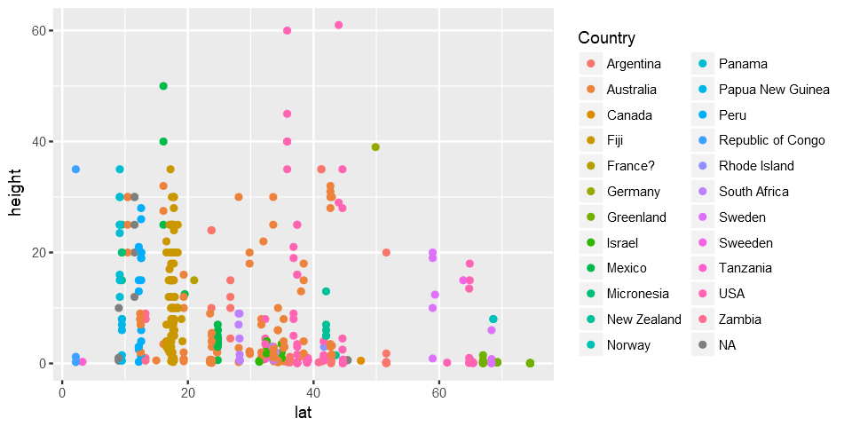

```r
plantHeight %>%
    ggplot(aes(x = lat, y = height, colour = Country)) +
    geom_point()
```

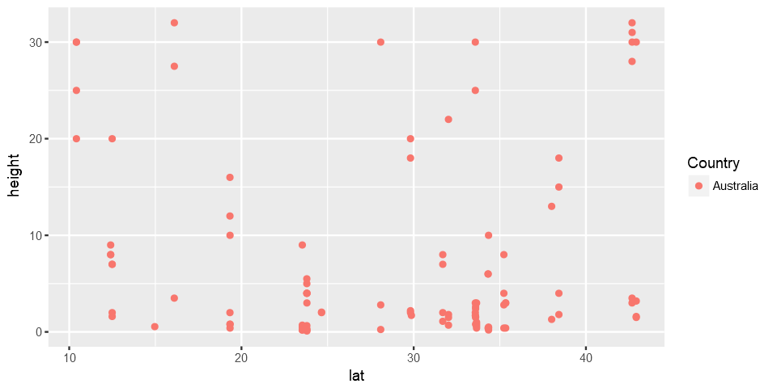

```r
plantHeight %>%
  filter(Country == "Australia") %>%
  ggplot(aes(x = lat, y = height, col = Country)) +
  geom_point()
```

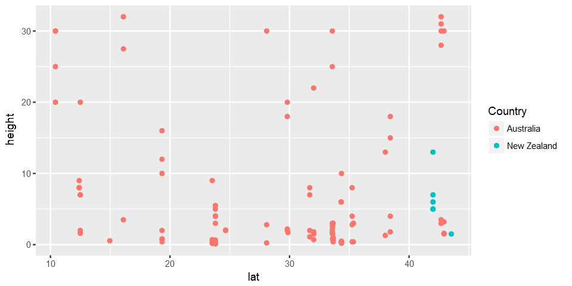

```r
plantHeight %>%
  filter(Country == "Australia"|Country=="New Zealand") %>%
  ggplot(aes(x = lat, y = height, col = Country)) +
  geom_point()
```

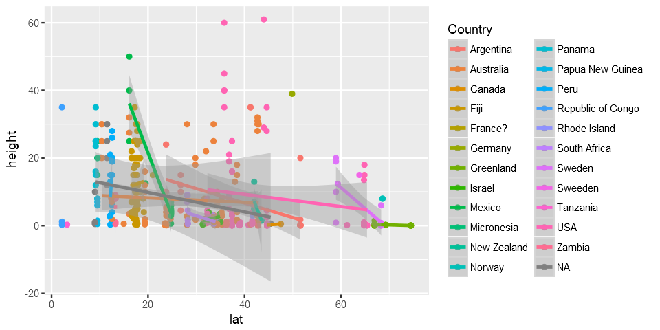

```r
plantHeight %>%
  ggplot(aes(x = lat, y = height, col = Country)) +
  geom_point() +
  geom_smooth(method = "lm")
```

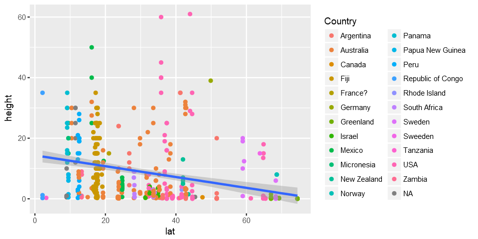

```r
plantHeight %>%
  ggplot(aes(x = lat, y = height)) +
  geom_point(aes(col = Country)) +
  geom_smooth(method = "lm")
```

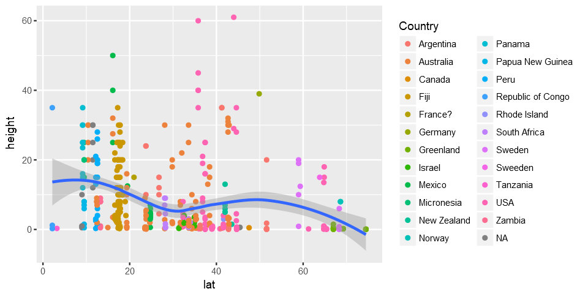

```r
plantHeight %>%
  ggplot(aes(x = lat, y = height)) +
  geom_point(aes(col = Country)) +
  geom_smooth(method = "loess")
```

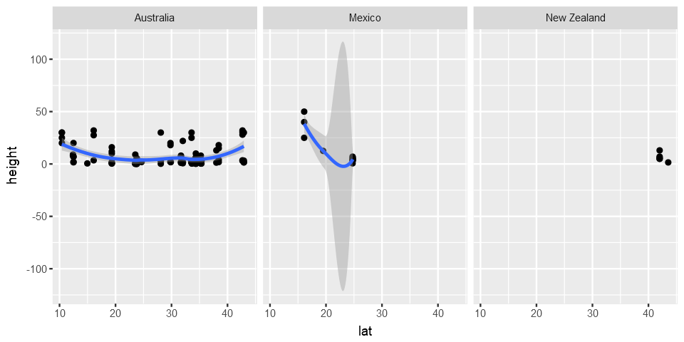

```r
plantHeight %>%
  filter(Country %in% c("Australia", "New Zealand", "Mexico")) %>%
  ggplot(aes(x = lat, y = height)) +
  geom_point() +
  geom_smooth(method = "loess") +
  facet_grid(.~Country)
```

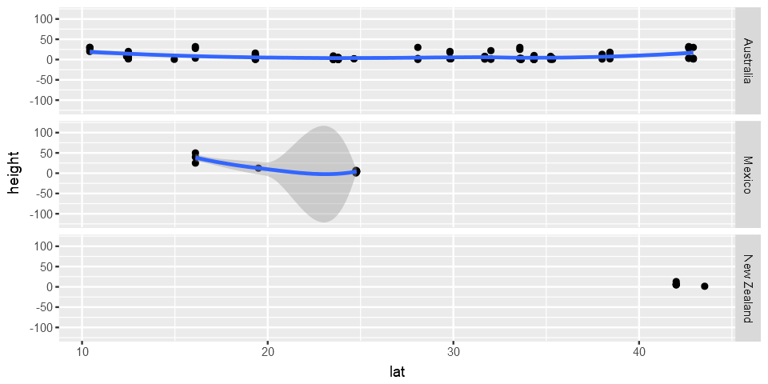

```r
plantHeight %>%
  filter(Country %in% c("Australia", "New Zealand", "Mexico")) %>%
  ggplot(aes(x = lat, y = height)) +
  geom_point() +
  geom_smooth(method = "loess") +
  facet_grid(Country~.)
```